# Projekt z przedmiotu Metody Walidacji Modeli Statystycznych

## Boosting

Boosting a dokładniej Gradient Boosting Machine (GBM) to technika uczenia maszynowego, która polega na łączeniu wielu słabych modeli uczących w celu stworzenia silnego modelu predykcyjnego. W odróżnieniu od baggingu, gdzie modele uczą się niezależnie, w boostingu każdy kolejny model jest trenowany tak, aby skupić się na obszarach, w których poprzednie modele popełniły błędy. Podczas procesu trenowania, boosting waży błędnie sklasyfikowane lub źle dopasowane przykłady danych, co prowadzi do lepszego radzenia sobie z trudnymi przypadkami.

**Porównanie metryk na zbiorze treningowym i testowym**

| Metryki | Train | Test |
| --- | --- | --- |
| accuracy | 0.9407 | 0.9338 |
| precision | 0.9356 | 0.9335 |
| recall | 0.9608 | 0.9501 |
| F1-score | 0.9480 | 0.9417 |

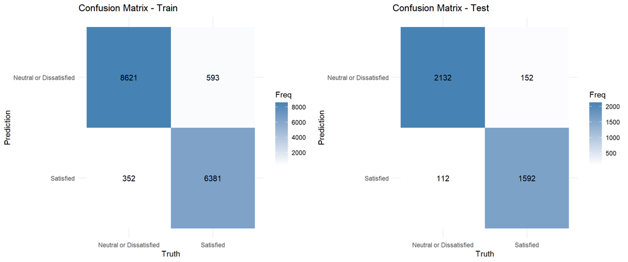

Model Boosting przed strojoną parametryzacją osiągnął bardzo dobre wyniki zarówno na zbiorze treningowym, jak i testowym. Dokładność (accuracy) na zbiorze treningowym wyniosła 94,07%, a na zbiorze testowym 93,38%. Świadczy to o dobrej zdolności modelu do generalizacji – nie wystąpiło nadmierne dopasowanie do danych treningowych.

**Tuning modelu Boosting (XGBoost)**

W celu poprawy jakości predykcji przeprowadzono tuning hiperparametrów modelu Boosting, opartego na algorytmie XGBoost. W tym procesie dostrajano pięć najistotniejszych parametrów, mających wpływ na głębokość drzew, szybkość uczenia, regularyzację oraz losowość treningu:

- `tree_depth` – maksymalna głębokość pojedynczego drzewa; kontroluje stopień złożoności modelu. Zakres wartości: od 2 do 10.
- `learn_rate` – współczynnik uczenia; określa, jak dużą wagę przypisuje się każdemu kolejnemu drzewu w iteracji boostingowej. Przeszukiwany zakres logarytmiczny: od $10^{−4}$ do $10^{−1}$.
- `loss_reduction` – minimalna wartość zmniejszenia funkcji straty, wymagana do wykonania podziału w drzewie (odpowiednik gamma w XGBoost). Zakres: od 0.1 do 100 (logarytmicznie od -1 do 2).
- `sample_prop` – proporcja obserwacji losowo wybieranych do trenowania każdego drzewa (subsampling). Zakres: od 0.5 do 1.0.
- `mtry` – liczba predyktorów losowo wybieranych na potrzeby konstrukcji drzew; zakres: od 1 do 22 (czyli liczba predyktorów w zbiorze danych).

Do przeszukiwania przestrzeni hiperparametrów zastosowano siatkę regularną (grid_regular) z trzema poziomami dla każdego parametru, co dało łącznie 243 kombinacje (3⁵).

Liczba drzew (trees) została ustalona na stałym poziomie 100, aby ograniczyć czas obliczeń przy zachowaniu dobrej reprezentatywności modelu.

**Porównanie metryk na zbiorze treningowym i testowym po tuningu**

[output not shown]

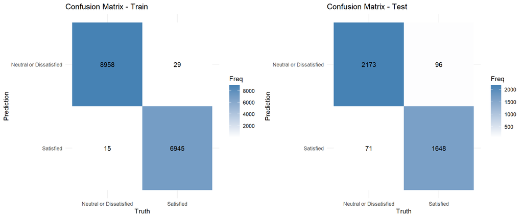

Macierz konfuzji po tuningu pokazała znaczący wzrost liczby trafnych klasyfikacji oraz dalszy spadek liczby błędów fałszywie pozytywnych i negatywnych. W szczególności zwiększyła się skuteczność wykrywania przypadków zadowolonych klientów, przy jednoczesnym ograniczeniu błędnych identyfikacji. Choć tak wysoka skuteczność na danych treningowych może sugerować przeuczenie, utrzymanie wysokiej jakości klasyfikacji na danych testowych wskazuje, że model jest stabilny i dobrze zoptymalizowany.

## SVM

SVM (Support Vector Machine) to potężny algorytm uczenia maszynowego stosowany zarówno w zadaniach klasyfikacji, jak i regresji. Jego podstawowym celem jest znalezienie optymalnej hiperpłaszczyzny lub zestawu hiperpłaszczyzn, które najlepiej separują dane wejściowe na różne klasy lub przewidują wartości dla danych numerycznych. SVM działa poprzez znalezienie hiperpłaszczyzny o największym marginesie, czyli największej możliwej odległości między punktami danych różnych klas. Punktami, które leżą najbliżej hiperpłaszczyzny, nazywane są wektorami nośnymi (support vectors), a są one kluczowe dla określenia położenia hiperpłaszczyzny decyzyjnej.

**Porównanie metryk na zbiorze treningowym i testowym**

| Metryki | Train | Test |
| --- | --- | --- |
| accuracy | 0.9608 | 0.9493 |
| precision | 0.9552 | 0.9510 |
| recall | 0.9762 | 0.9594 |
| F1-score | 0.9656 | 0.9552 |

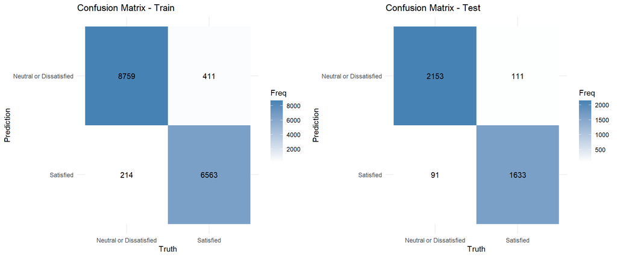

Model SVM został przetestowany bez strojenia hiperparametrów i uzyskał bardzo dobre wyniki klasyfikacyjne. Na zbiorze treningowym osiągnął dokładność (accuracy) na poziomie 96,08%, natomiast na zbiorze testowym – 94,93%. Taka niewielka różnica między wynikami dla obu zbiorów świadczy o dobrej zdolności generalizacji i braku oznak przeuczenia modelu.

**Uwaga dotycząca modelu SVM:**

W projekcie nie przeprowadzono tuningu hiperparametrów dla modelu SVM. Podjęta została próba optymalizacji, jednak z uwagi na ograniczenia sprzętowe komputera – w szczególności niewystarczającą moc obliczeniową i brak dedykowanego GPU – proces strojenia hiperparametrów okazał się bardzo czasochłonny. W trakcie prób proces uczenia trwał ponad 15 godzin i nie zakończył się nawet po tym czasie, co zmusiło mnie do przerwania dalszych eksperymentów. Ze względu na nieefektywność obliczeniową oraz ograniczony czas realizacji projektu, zdecydowano się pozostać przy wynikach uzyskanych dla domyślnych parametrów modelu.

# Wnioski

**Porównanie modeli na zbiorach Train i Test**

| Model | Dataset | Accuracy | Precision | Recall | F1-score |
| --- | --- | --- | --- | --- | --- |
| Regresja logistyczna | Train | 0.9355 | 0.9347 | 0.9520 | 0.9432 |
| Regresja logistyczna | Test | 0.9290 | 0.9333 | 0.9412 | 0.9372 |
| Regresja logistyczna tuning | Train | 0.9243 | 0.9231 | 0.9442 | 0.9335 |
| Regresja logistyczna tuning | Test | 0.9140 | 0.9185 | 0.9296 | 0.9240 |
| Drzewo decyzyjne | Train | 0.8894 | 0.8819 | 0.9277 | 0.9042 |
| Drzewo decyzyjne | Test | 0.8809 | 0.8801 | 0.9127 | 0.8961 |
| Drzewo decyzyjne tuning | Train | 0.9382 | 0.9277 | 0.9655 | 0.9462 |
| Drzewo decyzyjne tuning | Test | 0.9273 | 0.9237 | 0.9492 | 0.9363 |
| Random Forest | Train | 0.9880 | 0.9827 | 0.9962 | 0.9894 |
| Random Forest | Test | 0.9411 | 0.9335 | 0.9639 | 0.9485 |
| Random Forest tuning | Train | 0.9991 | 0.9986 | 0.9999 | 0.9992 |
| Random Forest tuning | Test | 0.9559 | 0.9555 | 0.9666 | 0.9610 |
| XGBoost | Train | 0.9407 | 0.9356 | 0.9608 | 0.9480 |
| XGBoost | Test | 0.9338 | 0.9335 | 0.9501 | 0.9417 |
| XGBoost tuning | Train | 0.9972 | 0.9968 | 0.9983 | 0.9976 |
| XGBoost tuning | Test | 0.9581 | 0.9577 | 0.9684 | 0.9630 |
| SVM | Train | 0.9608 | 0.9552 | 0.9762 | 0.9656 |
| SVM | Test | 0.9493 | 0.9510 | 0.9594 | 0.9552 |

Na podstawie przedstawionych wyników można wyciągnąć wnioski, które modele sprawdziły się najlepiej. Najwyższą skuteczność na zbiorze testowym osiągnęły modele XGBoost po tuningu, Random Forest po tuningu oraz SVM. Model XGBoost tuning uzyskał najlepszy wynik F1 na danych testowych (0.9630), co oznacza bardzo dobrą równowagę między precyzją a czułością. Random Forest tuning również osiągnął bardzo dobre wyniki (F1 = 0.9610), jednak jego dokładność na zbiorze treningowym była niemal idealna (0.9991), co może wskazywać na przeuczenie. SVM, mimo że nie był dostrajany, zaprezentował się bardzo dobrze i stabilnie, osiągając F1 = 0.9552 na teście i brak dużych różnic między treningiem a testem.

Regresja logistyczna, choć prostsza, dała przyzwoite wyniki (F1 = 0.9372 na teście), jednak ustępuje bardziej zaawansowanym algorytmom. Modele drzew decyzyjnych, zwłaszcza po tuningu, poprawiły swoje rezultaty, ale nadal nie osiągnęły poziomu XGBoost czy Random Forest.

Widać, że najbardziej złożone modele, takie jak XGBoost i Random Forest, oferują najlepszą skuteczność, ale mogą też być podatne na przeuczenie. Z kolei SVM pokazuje, że można uzyskać bardzo dobre wyniki bez konieczności intensywnego dostrajania parametrów. Wybór najlepszego modelu powinien więc zależeć nie tylko od wskaźników, ale również od równowagi między skutecznością a ogólną zdolnością do generalizacji.